# hclust

```r
library(tidyverse)
library(data.table)
```

```r
pI_tab <- read.delim(
  "C:/Users/kayle/Box/Vertinolab/GenomicSandbox/project_cell_lines/ProSeq/pI/V3/project_cell_lines_pI.txt"
  )
```

```r
pI_tab_simple = pI_tab[,c(1:4, 19, 26, 33, 40, 47)]
```

```r
pI_tab_simple = pI_tab_simple %>%
  separate(symbol, into=c("symbol", NA), sep = "_") %>% filter(!grepl('chrY|chrX', chrom))
```

Previously, did NA as 0. This time, remove all NA.

```r
pI_tab_no_na = pI_tab_simple %>%
            filter(!is.na(pI.MCF7) &
                     !is.na(pI.SUM159) &
                     !is.na(pI.MCF10A) &
                     !is.na(pI.T47D) &
                     !is.na(pI.MB231)                   )
```

3006 genes z score normalize get information first

```r
pI_tab_log10 = cbind(
  pI_tab_no_na[,1:4], log10(as.matrix(pI_tab_no_na[,5:9])+1)
  )
```

(log10 is +1 to avoid inducing na by attempting to do log(0). Pretty standard). Okay, this time get variance before normalizing all the variance away

```r
pI_znorm = pI_tab_log10 %>%
  rowwise() %>%
  mutate(stdev = sd(c(pI.MCF7, pI.SUM159, pI.MCF10A, pI.T47D, pI.MB231)), meanpi = mean(c(pI.MCF7, pI.SUM159, pI.MCF10A, pI.T47D, pI.MB231)), pivar = var(c(pI.MCF7, pI.SUM159, pI.MCF10A, pI.T47D, pI.MB231))) %>%
  filter(stdev!=0) #for anything that's all 0s
```

```r
pI_znorm$MCF7norm = (pI_znorm$pI.MCF7-pI_znorm$meanpi)/pI_znorm$stdev
pI_znorm$SUM159norm = (pI_znorm$pI.SUM159-pI_znorm$meanpi)/pI_znorm$stdev
pI_znorm$MCF10Anorm = (pI_znorm$pI.MCF10A-pI_znorm$meanpi)/pI_znorm$stdev
pI_znorm$T47Dnorm = (pI_znorm$pI.T47D-pI_znorm$meanpi)/pI_znorm$stdev
pI_znorm$MB231norm = (pI_znorm$pI.MB231-pI_znorm$meanpi)/pI_znorm$stdev
```

```r
pI_znorm_top500 <- pI_znorm %>%
  arrange(desc(pivar)) %>%
  slice(1:500)
```

```r
pI_mat = as.matrix(pI_znorm_top500[,13:17])
rownames(pI_mat) = pI_znorm_top500[[4]]
colnames(pI_mat) = c("MCF7", "SUM159", "MCF10A", "T47D", "MB231")
```

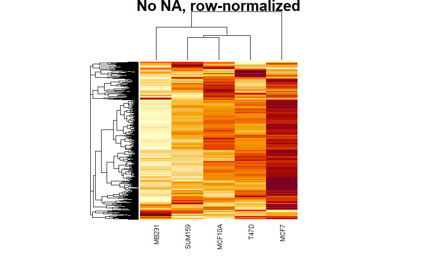

```r
heatmap(pI_mat, scale="none", cexCol = 0.8, labRow = "", main = "No NA, row-normalized")
```

What about without Znorm?

```r
pI_mat2 = as.matrix(pI_znorm_top500[,5:9])
rownames(pI_mat2) = pI_znorm_top500[[4]]
colnames(pI_mat2) = c("MCF7", "SUM159", "MCF10A", "T47D", "MB231")
```

Ignore this one, I don’t think it gives any useful insights.

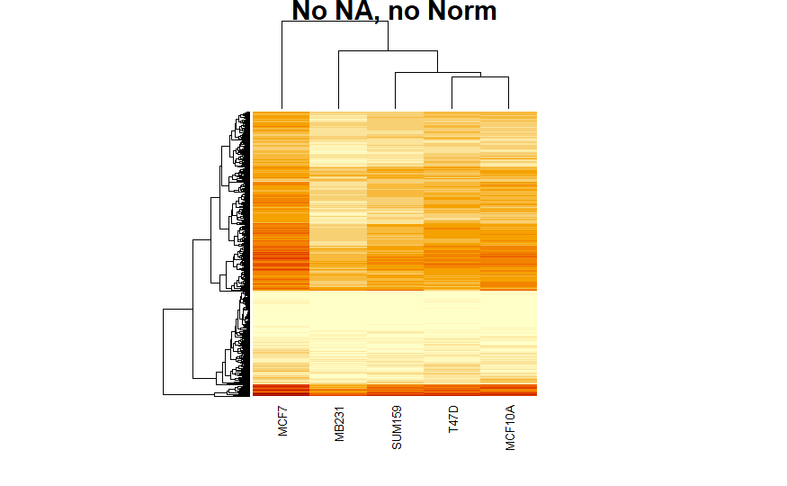

```r
heatmap(pI_mat2, scale="none", cexCol = 0.8, labRow = "", main="No NA, no Norm")
```

what. That didn’t happen previously??? So what are the differences? In the previous graph I did NA as 0, because I wasn’t 100% sure what they meant biologically (not enough reads in the gene body yes, but are they necessarily all that different from genes with a score of 0? IDK). I also took the top 10% variance instead of the tope 500 variance, but I doubt that’s affecting things much. Chunks 1-4 were identical, then handled NA. Log norm and calculating var were identical. I’m also testing this with the old filtering just in case.

Let’s do this with NA as 0. So…

```r
pI_tab_na_as_0 = pI_tab_simple %>%
            mutate(pI.MCF7 = replace_na(pI.MCF7, 0),
                   pI.SUM159 = replace_na(pI.SUM159, 0),
                   pI.MCF10A = replace_na(pI.MCF10A, 0),
                   pI.T47D = replace_na(pI.T47D, 0),
                   pI.MB231 = replace_na(pI.MB231, 0)
                   )
```

```r
pI_tab_log10_3 = cbind(
  pI_tab_na_as_0[,1:4], log10(as.matrix(pI_tab_na_as_0[,5:9])+1)
  )
```

```r
pI_znorm3 = pI_tab_log10_3 %>%
  rowwise() %>%
  mutate(stdev = sd(c(pI.MCF7, pI.SUM159, pI.MCF10A, pI.T47D, pI.MB231)), meanpi = mean(c(pI.MCF7, pI.SUM159, pI.MCF10A, pI.T47D, pI.MB231)), pivar = var(c(pI.MCF7, pI.SUM159, pI.MCF10A, pI.T47D, pI.MB231))) %>%
  filter(stdev!=0)
```

```r
pI_znorm3$MCF7norm = (pI_znorm3$pI.MCF7-pI_znorm3$meanpi)/pI_znorm3$stdev
pI_znorm3$SUM159norm = (pI_znorm3$pI.SUM159-pI_znorm3$meanpi)/pI_znorm3$stdev
pI_znorm3$MCF10Anorm = (pI_znorm3$pI.MCF10A-pI_znorm3$meanpi)/pI_znorm3$stdev
pI_znorm3$T47Dnorm = (pI_znorm3$pI.T47D-pI_znorm3$meanpi)/pI_znorm3$stdev
pI_znorm3$MB231norm = (pI_znorm3$pI.MB231-pI_znorm3$meanpi)/pI_znorm3$stdev
```

```r
pI_znorm_top500_3 <- pI_znorm3 %>%
  arrange(desc(pivar)) %>%
  slice(1:500)
```

Now I need to hclust in both directions.

```r
pI_mat3 = as.matrix(pI_znorm_top500_3[,13:17])
rownames(pI_mat3) = pI_znorm_top500_3[[4]]
colnames(pI_mat3) = c("MCF7", "SUM159", "MCF10A", "T47D", "MB231")
```

NA as 0, Znorm by rows:

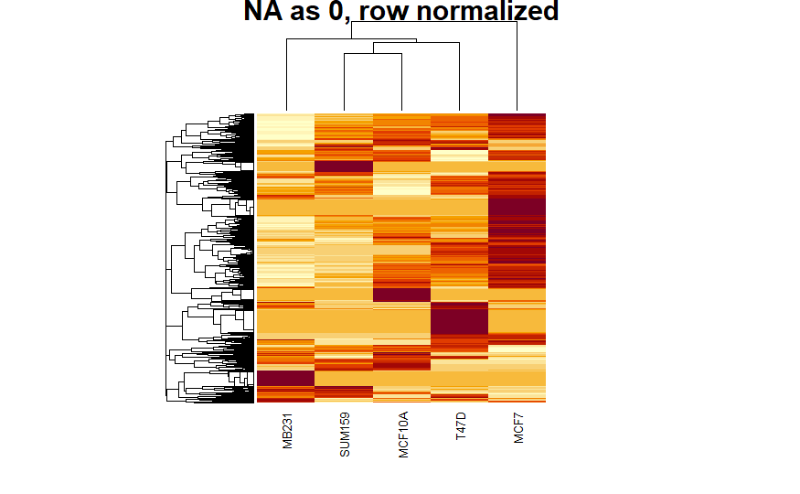

```r
heatmap(pI_mat3, scale="none", cexCol = 0.8, labRow = "", main = "NA as 0, row normalized")
```

```r
pI_mat4 = as.matrix(pI_znorm_top500_3[,5:9])
rownames(pI_mat4) = pI_znorm_top500_3[[4]]
colnames(pI_mat4) = c("MCF7", "SUM159", "MCF10A", "T47D", "MB231")
```

NA as 0

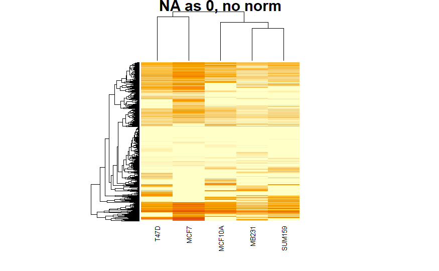

```r
heatmap(pI_mat4, scale="none", cexCol = 0.8, labRow = "", main = "NA as 0, no norm")
```

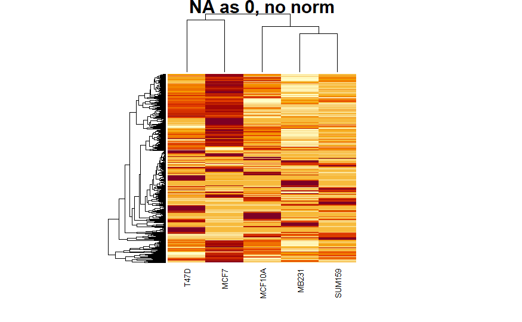

```r
heatmap(pI_mat4, scale="row", cexCol = 0.8, labRow = "", main = "NA as 0, no norm")
```